# Multilayer Perceptron

## Discovering Patterns in the Russian Housing Market for Analysis and Prediction

### 3804ICT Assignment Part I | Multilayer Perceptron | Trimester 2, 2019

Joshua Russell (s5057545) | joshua.russell2@griffithuni.edu.au

Joshua Mitchell (s5055278) | joshua.mitchell4@griffithuni.edu.au

Hayden Flatley (s5088623) | hayden.flatley@griffithuni.edu.au

### 1. Introduction

#### 1.1. Aim

The aim of this investigation is to develop a model for predicting Russian house prices based upon information about the property and the surrounding area. Predicting house prices would not only allow home buyers and sellers to more objectively evaluate the value of properties, but it would also give real estate businesses and banks additional knowledge to use for assisting their customers. We will use a feedforward artificial neural network known as the multilayer perceptron for this task of regression. The following section introduces the multilayer perceptron.

#### 1.2. Multilayer Perceptron

The multilayer perceptron (MLP) is a type of artificial neural network which is capable of learning a complex mathematical function. In this investigation we are performing regression analysis, where we would like to learn the relationship between a dependent variable (i.e. property sale price) and multiple independent variables (i.e. property and neighbourhood attributes). Once we have learnt this relationship, we can predict the value of the dependent variable given a set of independent variable values. Consequently, the mathematical function we would like our MLP to learn, is a function $f$, or regression model, that maps a certain input feature vector $\boldsymbol{x}$ (consisting of property and neighbourhood attribute values) to a continuous valued output $y$ (representing property sale price):

$$ y = f_{\theta}(\boldsymbol{x}) $$

where the function $f$ is parameterised by $\theta$. The parameters which make up $\theta$ are known as the weights of the network. These weights determine how the input $\boldsymbol{x}$ propagates through the network to produce a particular output $y$. Thus, we would like the network to "learn" what the parameters $\theta$ should be, such that the mapping from property and neighbourhood attributes to a predicted property sale price is as accurate as possible. Before discussing the method for learning these parameters, we will explain the structure of the MLP.

As the name implies, the MLP is made up of multiple layers of perceptrons. There is an input layer, which takes in the input feature vector $\boldsymbol{x}$, an output layer, where the prediction $y$ is made, and in between these layers there are the hidden layers, which perform a sequence of mathematical manipulations on the input data to produce an output. Each of these layers is made up of $k$ mathematical "units" known as perceptrons. Formally, perceptrons take a set of inputs $\boldsymbol{x} = (x_0, x_1, x_2, ..., x_m)$ that are each weighted by a set of corresponding weights $\boldsymbol{w} = (w_0, w_1, w_2, ..., w_m)$, sums the weighted inputs together, and then applies a non-linear activation function $\varphi$ to the sum in order to produce an output $y$:

$$y_k = \varphi \left( \sum\limits_{j=0}^{m} w_{kj} x_j \right)$$

where $ \varphi(z) = \frac{1}{1 + e^{-z}} $ in this investigation (i.e. each mathematical unit uses the sigmoid activation function). In MLPs, each perceptron in a given layer is connected to all of the perceptrons in the subsequent layer. This fully connected, layered structure of mathematical units allows the MLP to learn complex mathematical mappings from the input vector to the desired output value. Through examining the function above, we can appreciate that the weights of the perceptrons are the only values in the network that change how a given input is mapped to a certain output. This is why the weights of the network, as previously stated, are what parameterises the mathematical function of the MLP. Moreover, we can appreciate that there would be certain values for these weights that would produce accurate predictions, and certain values that would make the network output predictions that seem completely random in regard to the domain of the task. The motivation behind learning, is that we want to determine the optimal value for each of the weights in the network, such that the mathematical mapping between input feature vectors and output predictions is as accurate as possible.

Supervised learning provides us with a way of learning such values for the weights of the network. In supervised learning, models are trained on input-output pairs. These pairs essentially tell the model that for a particular input there is a certain output that should be produced. In our task of predicting Russian house prices based upon information about the property and the surrounding area, the input-output pairs would consist of the property and neighbourhood attribute values of a home (input) and the corresponding sale price (output). If we were to randomly initialise our weights to arbitrary values, we could then pass the $n$ input feature vectors of our training set to the MLP and record its predictions. To quantify the model's performance, we could then use an error function such as mean squared error (MSE), which calculates the squared distance between the true output $y$ of our input-output pair and the predicted output of the MLP:

$$MSE = \frac{1}{n} \sum\limits_{i=1}^{n} \left( y_i - f_{\theta}(x_i) \right) ^2$$

Intuitively, if the MSE is large it means that our model is performing poorly on the training set, and if our MSE is low it means that our model if performing well (i.e. it is rather accurately predicting the sale prices of properties, given information about the property and the surrounding area). Having such a measure to assess the performance of our model allows us to frame learning the optimal weights of the network as an optimization problem. As the optimal weights will provide us with a low MSE. An efficient way to change the weights of the network with respect to the error function is to determine the gradient of the error function with respect to the weights. If we know this gradient, we can update the value of a particular weight by moving it in the direction that minimises the error function. Thus, making the overall error of the network decrease and the accuracy of the network increase. This method of minimising the error function based upon its gradient with respect to the weights of the network is known as gradient descent. Furthermore, the way in which we efficiently calculate such gradients to perform a gradient descent step is known as backpropagation. In practice, since we are applying these weight updates over many training steps, it is typically too computationally expensive to calculate the gradient using every input-output pair in the training set. We solve this problem by effectively estimating the gradient from a batch of randomly selected input-output pairs. This training algorithm is known as stochastic gradient descent, and it is able to iteratively update the weights of the network in order to find a local minimum in the error function so that the MLP is able to accurately map given input vectors to their corresponding true outputs. Once the MLP has learnt the desired mathematical function from input-output training pairs, we can use a test set to evaluate how well the model generalises to unseen data.

In the investigation that follows, we use the MLP to predict Russian house prices based upon information about the property and the surrounding area.

#### 1.3. References

- Nielsen, M. (2015). *Neural Networks and Deep Learning*. Determination Press.

### 2. Preprocessing

Here we import library modules, load the Russian housing market datasets and preprocess the data for the task of regression with the multilayer perceptron.

```python
# Imports
import time
import random
import numpy as np
import pandas as pd
import seaborn as sns
import tensorflow as tf
import matplotlib.pyplot as plt

from tqdm import tqdm
from sklearn import metrics
from sklearn import preprocessing
from sklearn.neural_network import MLPRegressor
from sklearn.utils.testing import ignore_warnings
from sklearn.exceptions import ConvergenceWarning
from tensorflow.keras import optimizers
from tensorflow.keras.models import Sequential
from tensorflow.keras.layers import Dense, Dropout
```

Known dependencies: `pandas-0.25.1`

```python
# Load the Russian Housing Market datasets into pandas DataFrames
df_test = pd.read_csv("Data/test.csv")
df_train = pd.read_csv("Data/train.csv")

# Add a 'price_doc' column to the test DataFrame filled with NaN values
df_test = df_test.assign(price_doc=pd.Series([np.nan for i in range(df_test.shape[0])]).values)

# Add an 'identifier' column to the test DataFrame filled with "TEST" string values
df_test = df_test.assign(identifier=pd.Series(["TEST" for i in range(df_test.shape[0])]).values)

# Add an 'identifier' column to the train DataFrame filled with "TRAIN" string values
df_train = df_train.assign(identifier=pd.Series(["TRAIN" for i in range(df_train.shape[0])]).values)

# Concatenate test and train DataFrames
df = pd.concat([df_train, df_test], sort=False, ignore_index=True)

# Concatenate datasets (both training and testing data samples)
print("Complete dataset\n- No. data samples: {}\n- No. of attributes: {}".format(df.shape[0], df.shape[1]))
```

```
Complete dataset
- No. data samples: 38133
- No. of attributes: 293
```

```python
# Convert the `timestamp` attribute into `years`, `months`, `days`
years = df["timestamp"].str[:4]
months = df["timestamp"].str[5:7]
days = df["timestamp"].str[8:10]
df = df.assign(year=pd.Series(years.astype("int64")).values)
df = df.assign(month=pd.Series(months.astype("int64")).values)
df = df.assign(day=pd.Series(days.astype("int64")).values)
df = df.drop("timestamp", 1)
```

```python
# Define the property and neighbourhood attributes that will not be used for predicting the sale price of properties
remove_list = ["identifier", "price_doc", "hospital_beds_raion", "cafe_sum_500_min_price_avg", "cafe_sum_500_max_price_avg",
               "cafe_avg_price_500", "cafe_sum_1000_min_price_avg", "cafe_sum_1000_max_price_avg", "cafe_avg_price_1000"]

# Define the attributes that will be used for property sale price prediction, and remove the attributes contained
# within the list defined above
attributes = list(df.columns)
for a in remove_list:
    attributes.remove(a)

# Drop the attributes from the DataFrame that will not be used in training or testing
drop_list = ["hospital_beds_raion", "cafe_sum_500_min_price_avg", "cafe_sum_500_max_price_avg", "cafe_avg_price_500",
             "cafe_sum_1000_min_price_avg", "cafe_sum_1000_max_price_avg", "cafe_avg_price_1000"]

for a in drop_list:
    df = df.drop(a, 1)
```

#### 2.1. Data Cleaning

Preprocessing steps for cleaning noisy data values are taken from our *Part 1: Data Investigation Notebook*.

```python
# Set the properties with `floor` or `max_floor` as null to have values of 1 for `floor` / `max_floor`
df.loc[df.floor.isnull(), 'floor'] = 1
df.loc[df.floor.isnull(), 'max_floor'] = 1

# Set the properties with `floor` greater than `max_floor` to have a `max_floor` equal to that of `floor`
df.loc[(df['floor'] > df['max_floor']), 'max_floor'] = df.loc[(df['floor'] > df['max_floor']), 'floor']

# Drop the data sample with a `state` value of 33
df = df.drop(df[(df.state > 4)].index)

# Set `full_sq` to be equal to `life_sq` in the cases where life_sq > full_sq
df.loc[(df.life_sq > df.full_sq), 'full_sq'] = df[(df.life_sq > df.full_sq)]["life_sq"]

# Drop the data samples with `build year` greater than 2019 or less than 1000
df = df.drop(df[(df.build_year > 2019) | (df.build_year < 1000)].index)

# Drop the remaining data samples that contain NaN values for any of the chosen attributes
df = df.dropna(subset=attributes)

# Display the dataset size after preprocessing
print("Preprocessed dataset\n- No. data samples: {}\n- No. of attributes: {}".format(df.shape[0], df.shape[1]))
```

```
Preprocessed dataset
- No. data samples: 17463
- No. of attributes: 288
```

#### 2.2. Data Transformation and Data Discretization

Here we transform nominal and ordinal attribute values into a discrete set of numbers (i.e. `["No", "Yes"] -> [0, 1]`).

```python
# Display dataset attribute information
print("{:<50} {:<15} {:<25} {}".format("Attribute", "Data Type", "No. Unique Values", "Example Value"))
print("{:<50} {:<15} {:<25} {}".format("---------", "---------", "-----------------", "-------------"))
for a in df.columns:
    if len(set(df[a])) < 10 or str(df[a].dtype) == "object":
        print("{:<50} {:<15} {:<25} {}".format(a, str(df[a].dtype), len(set(df[a])), list(df[a])[1]))
```

```
Attribute                                          Data Type       No. Unique Values         Example Value
---------                                          ---------       -----------------         -------------
material                                           float64         5                         1.0
state                                              float64         4                         3.0
product_type                                       object          2                         Investment
sub_area                                           object          123                       Lianozovo
school_education_centers_top_20_raion              int64           3                         0
healthcare_centers_raion                           int64           7                         3
university_top_20_raion                            int64           4                         0
culture_objects_top_25                             object          2                         no
culture_objects_top_25_raion                       int64           6                         0
thermal_power_plant_raion                          object          2                         no
incineration_raion                                 object          2                         no
oil_chemistry_raion                                object          2                         no
radiation_raion                                    object          2                         yes
railroad_terminal_raion                            object          2                         no
big_market_raion                                   object          2                         no
nuclear_reactor_raion                              object          2                         no
detention_facility_raion                           object          2                         no
build_count_foam                                   float64         4                         0.0
build_count_mix                                    float64         9                         2.0
water_1line                                        object          2                         no
big_road1_1line                                    object          2                         no
railroad_1line                                     object          2                         no
ID_railroad_terminal                               int64           8                         101
ecology                                            object          5                         poor
trc_count_500                                      int64           9                         0
cafe_count_500_price_high                          int64           4                         0
mosque_count_500                                   int64           2                         0
market_count_500                                   int64           5                         0
cafe_count_1000_price_high                         int64           8                         0
mosque_count_1000                                  int64           2                         0
market_count_1000                                  int64           6                         0
mosque_count_1500                                  int64           2                         0
market_count_1500                                  int64           8                         1
mosque_count_2000                                  int64           2                         0
market_count_2000                                  int64           9                         2
mosque_count_3000                                  int64           3                         0
mosque_count_5000                                  int64           3                         1
identifier                                         object          2                         TRAIN
year                                               int64           4                         2013
```

```python
# Convert certain attribute values into a discrete set of numbers
attribute_encoders = {}
for a in df.columns:
    if a != "identifier":
        if len(set(df[a])) < 10 or str(df[a].dtype) == "object":
            encoder = preprocessing.LabelEncoder()
            encoder.fit(df[a])
            df[a] = encoder.transform(df[a])
            attribute_encoders[a] = encoder
```

#### 2.3. Data Standardization

Standardize the input feature vector dataset attributes to have zero mean and unit variance for training the MLPs:

$$ z = \frac{x - \mu}{\sigma}$$

where $x \in \boldsymbol{x}$ is the value to be standardized, $\mu$ is the mean of $\boldsymbol{x}$, $\sigma$ is the standard deviation of $\boldsymbol{x}$, and $z$ is the standardized value.

We standardize the input feature vector attributes since our dataset contains attributes with different units and scales (for example, the distance to the closest park `park_km` is a measure of distance in kilometres, whereas the subarea/district population `full_all` is a measure of the population count) (DeFilippi, 2018). Standardizing the distribution of the attribute values makes it so that regular points around the mean, and extreme points far from the mean are treated equally by the network across the various attributes.

#### References

- DeFilippi, R. (2018). Standardize or Normalize? — Examples in Python. Retrieved 24 September 2019, from https://medium.com/@rrfd/standardize-or-normalize-examples-in-python-e3f174b65dfc

```python
# Save the "identifier" and "price_doc" attribute values and create a list of attributes to standardize
identifier_series = df["identifier"]
price_doc_series = df["price_doc"]
df_columns = list(df.columns)
df_columns.remove("identifier")
df_columns.remove("price_doc")

# Standardize attributes to have zero mean and unit variance
scaler = preprocessing.StandardScaler()
scaled_df = scaler.fit_transform(df[df_columns].astype("float64"))

# Save scaler for "5.3. Predicting Russian House Prices based upon Information about the Property and the Surrounding Area"
attribute_standardizers = {}
standardized_columns = df_columns
for a in standardized_columns:
    standardization_scaler = preprocessing.StandardScaler()
    standardization_scaler.fit(np.array(df[a].astype("float64")).reshape(-1, 1))
    attribute_standardizers[a] = standardization_scaler

# Reconstruct DataFrame with standardized values
df = pd.DataFrame(scaled_df, columns=df_columns)
df = df.assign(identifier=pd.Series(identifier_series).values)
df = df.assign(price_doc=pd.Series(price_doc_series).values)
```

#### 2.4. Data Normalization

Normalize the property sale prices (i.e. the `price_doc` target attribute) to avoid numerical overflow with the sigmoid function. Here we use minmax normalization to normalize these values:

$$ z = \frac{x-min(\boldsymbol{x})}{max(\boldsymbol{x}) - min(\boldsymbol{x})}$$

where $x$ is the value to be normalized, $\boldsymbol{x}$ is the set of numbers from which $x$ is taken from, and $z$ is the normalized value.

```python
# Determine the maximum and minimum values of the attribute `price_doc`
price_doc_min = df["price_doc"].min()
price_doc_max = df["price_doc"].max()

def normalize(nums, nums_min, nums_max):
    """ Normalise an array using minmax normalization.

    :param nums: An array of numerical values within the range of [nums_min,nums_max].
    :param nums_min: The smallest value that elements within the given array could take on.
    :param nums_max: The largest value that elements within the given array could take on.
    :return: An array of normalized numerical values within the range of [0,1].
    """

    return np.divide(np.subtract(nums, nums_min), (nums_max - nums_min))

def reverse_normalize(nums, nums_min, nums_max):
    """ Reverse the minmax normalization applied to the values of the given array.

    :param nums: An array of normalized numerical values within the range of [0,1].
    :param nums_min: The smallest value that elements within the original array could take on.
    :param nums_max: The largest value that elements within the original array could take on.
    :return: An array of numerical values within the range of [nums_min,nums_max].
    """

    return np.add(nums_min, np.multiply(nums, (nums_max - nums_min)))

# Normalize the attribute `price_doc`
df["price_doc"] = normalize(np.array(df["price_doc"].values), price_doc_min, price_doc_max)
```

#### 2.5. Training and Test Set Preparation

We select the sub-dataframes which contain only the selected feature vector attributes and the target attribute for our investigation. We then create the training and test sets to be used for training and testing the multilayer perceptrons.

```python
# Split the DataFrame back into training and testing DataFrames
df_train = df[(df.identifier == "TRAIN")]
df_test = df[(df.identifier == "TEST")]

# Select sub-DataFrames of relevant attributes for the training and test sets
df_x_train = df_train[attributes].copy()
df_y_train = df_train[["price_doc"]].copy()
df_x_test_no_label = df_test[attributes].copy()

# Convert the DataFrames into numpy arrays
x_train = df_x_train.to_numpy()
y_train = df_y_train.to_numpy().reshape(len(df_y_train))
x_test_no_label = df_x_test_no_label.to_numpy()

# Shuffle the training data
zipped_training_data = list(zip(x_train, y_train))
random.shuffle(zipped_training_data)
x_train_shuffled, y_train_shuffled = zip(*zipped_training_data)
x_train_shuffled, y_train_shuffled = np.array(x_train_shuffled), np.array(y_train_shuffled)

# Split the training data into a training and test set (so that we have property sale prices to evaluate our models on).
# We decide to use 10% of the data for testing.
n = int(len(y_train_shuffled) * 0.1)
x_train = x_train_shuffled[:-n]
y_train = y_train_shuffled[:-n]
x_test = x_train_shuffled[-n:]
y_test = y_train_shuffled[-n:]

# Preprocess the datasets for the manual implementation of the Multilayer Perceptron
y_train_manual = y_train.reshape(-1, 1)

print("No. attributes within the input feature vectors: {}".format(x_train.shape[1]))
```

```
No. attributes within the input feature vectors: 286
```

### 3. Library Solutions

We implement the multilayer perceptron using two Python libraries, Scikit-learn and Keras. In our implementations, we use a network architecture consisting of one hidden layer.

#### Activation Functions

While implementing the library solutions, we were unsure about which activation function to use for the output layer of the network. After researching the topic online, we found that it is common to use either a linear or rectifier (i.e. ReLU) activation function (Ronaghan, 2018). For our library and manual solutions we decided to use the linear activation function, allowing the network to predict values within the range of $[-\infty, \infty]$.

#### References

- Ronaghan, S. (2018). Deep Learning: Which Loss and Activation Functions should I use?. Retrieved 25 September 2019, from https://towardsdatascience.com/deep-learning-which-loss-and-activation-functions-should-i-use-ac02f1c56aa8

#### 3.1. Scikit-learn

```python
@ignore_warnings(category=ConvergenceWarning)
def scikit_learn_MLP(x_train, y_train, x_test, epochs, verbose, batch_size, learning_rate, hidden_layer_size):
    """ Scikit-learn Multilayer Perceptron.

    :param x_train: Two dimensional array containing the training set feature vectors.
    :param y_train: One dimensional array containing the training set target values.
    :param x_test: Two dimensional array containing the test set feature vectors.
    :param epochs: An integer specifying the number of training epochs.
    :param verbose: A Boolean value indicating whether or not to display training updates.
    :param batch_size: An integer representing the mini-batch size to be used for training the network.
    :param learning_rate: A floating point number representing the learning rate to be used for training the network.
    :param hidden_layer_size: An integer specifying the number of neurons to use for the hidden layer.
    :return: A two element tuple holding a one dimensional array containing the predicted target values of the test set
             feature vectors, and another one dimensional array containing the training set MSE over all of the training
             epochs.
    """

    # Create a Multilayer Perceptron
    # (NOTE: since the specified activation function is "logistic", the weights of the network are
    # initialized using the Glorot normal initializer. Refer to the source code for confirmation:
    # https://github.com/scikit-learn/scikit-learn/blob/ef5cb84a/sklearn/neural_network/multilayer_perceptron.py#L300)
    mlp = MLPRegressor(hidden_layer_sizes=(hidden_layer_size), activation="logistic", solver="sgd", batch_size=batch_size,
                       learning_rate_init=learning_rate, max_iter=epochs, verbose=verbose, n_iter_no_change=epochs,
                       momentum=0.0, nesterovs_momentum=False)

    # Train the model on the training set
    mlp.fit(x_train, y_train)

    # Predict the property sale price based upon property and neighbourhood attributes
    y_pred = mlp.predict(x_test)

    # Return property sale price predictions and training set MSE over training epochs
    return y_pred, mlp.loss_curve_
```

#### 3.2. Keras

```python
def keras_MLP(x_train, y_train, x_test, epochs, verbose, batch_size, learning_rate, hidden_layer_size):
    """ Keras Multilayer Perceptron.

    :param x_train: Two dimensional array containing the training set feature vectors.
    :param y_train: One dimensional array containing the training set target values.
    :param x_test: Two dimensional array containing the test set feature vectors.
    :param epochs: An integer specifying the number of training epochs.
    :param verbose: A Boolean value indicating whether or not to display training updates.
    :param batch_size: An integer representing the mini-batch size to be used for training the network.
    :param learning_rate: A floating point number representing the learning rate to be used for training the network.
    :param hidden_layer_size: An integer specifying the number of neurons to use for the hidden layer.
    :return: A two element tuple holding a one dimensional array containing the predicted target values of the test set
             feature vectors, and another one dimensional array containing the training set MSE over all of the training
             epochs.
    """

    # Create a Multilayer Perceptron
    model = Sequential()
    model.add(Dense(hidden_layer_size, input_dim=x_train.shape[1], activation="sigmoid", kernel_initializer="glorot_normal"))
    model.add(Dense(1, activation="linear", kernel_initializer="glorot_normal"))
    sgd_optimizer = optimizers.SGD(lr=learning_rate, momentum=0.0, nesterov=False)
    model.compile(loss="mean_squared_error", optimizer=sgd_optimizer, metrics=["mse"])

    # Train the model on the training set
    if verbose:
        history = model.fit(x_train, y_train, epochs=epochs, batch_size=batch_size, verbose=1)
    else:
        history = model.fit(x_train, y_train, epochs=epochs, batch_size=batch_size, verbose=0)

    # Predict the property sale price based upon property and neighbourhood attributes
    y_pred = np.ravel(model.predict(x_test))

    # Return property sale price predictions and training set MSE over training epochs
    return y_pred, history.history["loss"]
```

### 4. Manual Solution

This section contains our manual implementation of the multilayer perceptron. In our implementation, we use a network architecture consisting of one hidden layer.

#### Weight Initialization

After manually implementing the multilayer perceptron, we conducted some experiments to compare the manual implementation with the two library solutions. We were surprised to find that although the mean squared error of the manual implementation was decreasing per epoch, it was taking significantly longer to converge in comparison to the library solutions. We hypothesised that the initialization of the weights of the network was the cause of this. Since if the network starts with weights that are further away from any local minima, it will naturally take longer to converge to a local minimum in the error function. Following some further research into the topic, we found that the convergence issue was in relation to the weight initialization and the gradient of the sigmoid activation function we were using. Because we were initialising our weights initially with `numpy.random.randn`, which samples values from a standard normal distribution, our weights were initialized to be "relatively" large. Thus, the weighted sums passing through the sigmoid activation functions would have been far away from zero. If we examine the sigmoid function, the slope of the function decreases more and more as we move further away from zero. As a result of this, we would get small gradients and in turn small updates to the weights of our network.

A solution proposed for this problem in *Understanding the difficulty of training deep feedforward neural networks*, is to use a truncated normal distribution with mean, $\mu = 0$, and standard deviation:

$$\sigma = \sqrt{\frac{2.0}{l\_in + l\_out}}$$

where $l\_in$ is the number of neurons in a given layer, and $l\_out$ is the number of neurons in the subsequent layer (Glorot & Bengio, 2010). After changing our weight initialization method to this technique (i.e. the Glorot normal initializer), our manually implemented multilayer perceptron began to take approximately the same amount of time to converge in comparison to the library solutions.

#### References

- Glorot, X., & Bengio, Y. (2010). Understanding the difficulty of training deep feedforward neural networks. *Journal Of Machine Learning Research*, 9, 249-256.

Additional Resources

- Determining which initialization method to use based upon the activation function: https://github.com/scikit-learn/scikit-learn/blob/ef5cb84a/sklearn/neural_network/multilayer_perceptron.py#L300
- Explanation of what occurs when using the standard normal/uniform distribution for weight initialization with the sigmoid function: https://stackoverflow.com/a/47241066/11427377

```python
class ManualMLP:
    """ Manual implementation of the Multilayer Perceptron."""

    def __init__(self, shape):
        """ Initialises variables for the ManualMLP class.

        :var shape: A three element tuple of integers specifying the number of neurons in each layer of the network,
                    i.e. (no. input neurons, no. hidden neurons, no. output neurons).
        :var W1: A matrix containing the weights of the network in between the input layer and the hidden layer.
        :var W2: A matrix containing the weights of the network in between the hidden layer and the output layer.
        """

        # Initialise class variables
        self.shape = shape

        # Initialise weights between the input layer and the hidden layer (Glorot normal initializer)
        mean = 0.0
        stddev = np.sqrt(2.0 / ((self.shape[0] + 1) + self.shape[1]))
        self.W1 = np.random.normal(mean, stddev, (self.shape[1], self.shape[0] + 1))

        # Initialise weights between the hidden layer and the output layer (Glorot normal initializer)
        mean = 0.0
        stddev = np.sqrt(2.0 / ((self.shape[1] + 1) + self.shape[2]))
        self.W2 = np.random.normal(mean, stddev, (self.shape[2], self.shape[1] + 1))

    def sigmoid(self, z):
        """ The sigmoid function.

        :param z: A matrix containing the weighted sum of neurons in the network.
        :return: A matrix containing the activation values of neurons in the network.
        """

        return 1 / (1 + np.exp(-z))

    def sigmoid_prime(self, s):
        """ The derivative of the sigmoid function.

        :param s: A matrix containing the activation values of neurons in the network.
        :return: A matrix containing the activation values with respect to z.
        """

        return s * (1 - s)

    def forward_pass(self, X):
        """ Computes a forward pass through the network to determine its predicted output.

        The relevant bias terms are appended onto the input matrix of each layer (i.e. X and ah) in order to
        take into account the activation of the bias neuron. The activation function of the final layer is "linear".

        :param X: A matrix containing the input vectors of the network.
        :return: A matrix containing the predicted output values of the network.
        """

        bias = np.ones((X.shape[0], 1))
        self.X_bias = np.hstack([X, bias])
        self.zh = np.dot(self.X_bias, self.W1.T)
        self.ah = self.sigmoid(self.zh)
        self.ah_bias = np.hstack([self.ah, bias])
        self.zo = np.dot(self.ah_bias, self.W2.T)
        out = self.zo

        return out

    def predict(self, X):
        """ Returns the predictions of the network for the given input vectors.

        :param X: A matrix containing the input vectors of the network.
        :return: A vector representing the predictions of the network for each input vector.
        """

        out = self.forward_pass(X)
        return out.reshape(out.shape[0])

    def back_propagation(self, X, y):
        """ Backpropagates the error of the network in order to determine how the network's weights
            should be updated.

        Uses mean squared error (i.e. quadratic loss or L2 loss) as the network's loss function.
        Note that since the activation function of the output layer is "linear", we do not calculate
        the derivative with respect to the sigmoid function in the final layer, only in the hidden layer.

        :param X: A matrix containing training input vectors.
        :param y: A vector containing true output values corresponding to the input vectors in X.
        :return: Two matrices representing the change in weights required to minimise the error of the network.
        """

        self.out = self.forward_pass(X)
        delta3 = -(y - self.out)
        delta_w2 = np.dot(self.ah_bias.T, delta3)
        w2_without_bias = np.delete(self.W2, self.shape[1], axis=1)
        delta2 = np.dot(delta3, w2_without_bias) * self.sigmoid_prime(self.ah)
        delta_w1 = np.dot(self.X_bias.T, delta2)

        return delta_w1.T, delta_w2.T

    def gradient_descent(self, X, y, batch_size, eta):
        """ Performs a single gradient descent step for training the network.

        Trains the neural network for one gradient descent step by back propagating the error of the current network
        in order to determine the change in weights required to minimise the mean squared error. The weights of the
        network are updated using stochastic gradient descent.

        :param X: A matrix containing `batch_size` training input vectors.
        :param y: A vector containing `batch_size` true output values corresponding to the input vectors in X.
        :param batch_size: An integer representing the mini-batch size to be used for training the network.
        :param eta: A floating point number representing the learning rate to be used for training the network.
        """

        gradient_w1, gradient_w2 = self.back_propagation(X, y)
        self.W1 += np.divide(-eta * gradient_w1, batch_size)
        self.W2 += np.divide(-eta * gradient_w2, batch_size)

    def train(self, x_train, y_train, epochs, batch_size, eta, verbose=True):
        """ Trains the network using stochastic gradient descent.

        :param x_train: A matrix containing training input vectors.
        :param y_train: A vector containing true output values corresponding to the input vectors in X.
        :param epochs: An integer specifying the number of training epochs.
        :param batch_size: An integer representing the mini-batch size to be used for training the network.
        :param eta: A floating point number representing the learning rate to be used for training the network.
        :param verbose: A Boolean value indicating whether or not to display training updates.
        :return: A one dimensional array containing the training set MSE over all of the training epochs.
        """

        # Define an array for keeping the history of MSE over training epochs
        mse_over_epochs = []

        for epoch in range(epochs):

            # Shuffle training data
            x_match_y = list(zip(x_train, y_train))
            random.shuffle(x_match_y)
            x_train, y_train = zip(*x_match_y)
            x_train, y_train = np.array(x_train), np.array(y_train)

            # Perform gradient descent steps to train the network
            for i in range(0, x_train.shape[0], batch_size):
                x_train_mini = x_train[i:i + batch_size]
                y_train_mini = y_train[i:i + batch_size]
                self.gradient_descent(x_train_mini, y_train_mini, batch_size, eta)

            if verbose:
                print("Epoch: {}".format(epoch + 1))
                y_pred = self.predict(x_train)
                print("MSE on Training Data: {}".format(metrics.mean_squared_error(y_train.reshape(y_train.shape[0]), y_pred)))

            y_pred = self.predict(x_train)
            mse_over_epochs.append(metrics.mean_squared_error(y_train.reshape(y_train.shape[0]), y_pred))

        return mse_over_epochs
```

```python
def manual_MLP(x_train, y_train, x_test, epochs, verbose, batch_size, learning_rate, hidden_layer_size):
    """ Manually implemented Multilayer Perceptron.

    :param x_train: Two dimensional array containing the training set feature vectors.
    :param y_train: One dimensional array containing the training set target values.
    :param x_test: Two dimensional array containing the test set feature vectors.
    :param epochs: An integer specifying the number of training epochs.
    :param verbose: A Boolean value indicating whether or not to display training updates.
    :param batch_size: An integer representing the mini-batch size to be used for training the network.
    :param learning_rate: A floating point number representing the learning rate to be used for training the network.
    :param hidden_layer_size: An integer specifying the number of neurons to use for the hidden layer.
    :return: A two element tuple holding a one dimensional array containing the predicted target values of the test set
             feature vectors, and another one dimensional array containing the training set MSE over all of the training
             epochs.
    """

    # Create a Multilayer Perceptron
    mlp = ManualMLP(shape=(x_train.shape[1], hidden_layer_size, 1))

    # Train the model on the training set
    history = mlp.train(x_train, y_train, epochs=epochs, batch_size=batch_size, eta=learning_rate, verbose=verbose)

    # Predict the property sale price based upon property and neighbourhood attributes
    y_pred = mlp.predict(x_test)

    # Return property sale price predictions and training set MSE over training epochs
    return y_pred, history
```

### 5. Results and Metrics

Within this section we provide experimental results on the Russian housing market dataset, compare the library implementations of the multilayer perceptron with our own, and explore how the multilayer perceptron could be used practically within the domain of the Russian housing market.

```python
# Helper variables
implementation_names = ["Scikit-learn", "Keras", "Manual"]
```

#### 5.1. Comparison between Implementations

This subsection compares the two library implementations (using Scikit-learn and Keras) of the multilayer perceptron with our manual implementation. We compare the implementations by examining their mean squared errors on the training set over training epochs, their mean squared errors on the test set, their mean absolute errors on the test set, their total training times, and their ability to predict property sale prices.

Note that the property sale prices were normalized into the range of $[0, 1]$.

#### Mean Squared Error

In the setting of this investigation, mean squared error (MSE) is defined as the average squared difference between the predicted values $f_{\theta}(x_i)$ and the actual values $y_i$ for all data samples $n$:

$$MSE = \frac{1}{n} \sum\limits_{i=1}^{n} \left( y_i - f_{\theta}(x_i) \right) ^2$$

If the MSE is large, it means that there is a large difference between the predicted values of the MLP and the actual values. If this were the case, then the MLP would be poorly predicting the actual property sale prices of data samples. In contrast, if the MSE is small, it means that there is a small difference between the predicted values of the MLP and the actual values. If this were the case, then the MLP would be accurately predicting the actual property sale prices of data samples. Simply, the lower the MSE the better.

#### Mean Absolute Error

In the setting of this investigation, mean absolute error (MAE) is defined as the average absolute difference between the predicted values $f_{\theta}(x_i)$ and the actual values $y_i$ for all data samples $n$:

$$MAE = \frac{1}{n} \sum\limits_{i=1}^{n} | y_i - f_{\theta}(x_i) |$$

If the MAE is large, it means that there is a large difference between the predicted values of the MLP and the actual values. If this were the case, then the MLP would be poorly predicting the actual property sale prices of data samples. In contrast, if the MAE is small, it means that there is a small difference between the predicted values of the MLP and the actual values. If this were the case, then the MLP would be accurately predicting the actual property sale prices of data samples. Simply, the lower the MAE the better.

#### MSE and MAE

Since MSE squares the errors, it penalizes larger differences more so than smaller differences. MAE does not have this characteristic and therefore is able to handle outliers better than MSE. Consequently, when evaluating the performance of the MLPs, MAE will provide an "unbiased" measurement of the average difference between the predicted values and the actual values. MSE is more useful in regard to training the network, as we may want the above characteristic in our error function in order to make the network focus on correcting itself where it is most incorrect. Moreover, using MSE as the error function of the network makes it much easier to compute the gradient in comparison to MAE.

#### Hyperparameters

```python
# Define hyperparameters for the comparisons
epochs = 1000
verbose = False
batch_size = 128
learning_rate = 0.001
hidden_layer_size = 1024
```

#### 5.1.1. Mean Squared Error on the Training Set over Training Epochs

```python
# Record the training durations of each implementation
training_durations = []

# Scikit-learn Multilayer Perceptron
start_time = time.clock()
y_pred_s, history_s = scikit_learn_MLP(x_train, y_train, x_test, epochs, verbose, batch_size, learning_rate, hidden_layer_size)
end_time = time.clock()
diff_time = end_time - start_time
training_durations.append(diff_time)

# Keras Multilayer Perceptron
start_time = time.clock()
y_pred_k, history_k = keras_MLP(x_train, y_train, x_test, epochs, verbose, batch_size, learning_rate, hidden_layer_size)
end_time = time.clock()
diff_time = end_time - start_time
training_durations.append(diff_time)

# Manually implemented Multilayer Perceptron
start_time = time.clock()
y_pred_m, history_m = manual_MLP(x_train, y_train_manual, x_test, epochs, verbose, batch_size, learning_rate, hidden_layer_size)
end_time = time.clock()
diff_time = end_time - start_time
training_durations.append(diff_time)
```

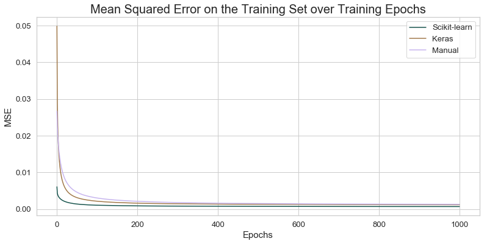

```python
# Create DataFrame of the experimental data
experimental_data = {"Epochs": [i for i in range(epochs)] * 3,
                     "MSE": history_s + history_k + history_m,
                     "Implementation": np.ravel([[n] * epochs for n in implementation_names])}

# Display a line plot of the training set mean squared errors as the number of epochs increases
sns.set(font_scale=1.2, style="whitegrid")
plt.figure(figsize=(13, 6))
ax = sns.lineplot(x="Epochs", y="MSE", hue="Implementation", data=experimental_data, palette="cubehelix")
ax.set_title("Mean Squared Error on the Training Set over Training Epochs", fontsize=20)
ax.set_ylabel("MSE", fontsize=15)
ax.set_xlabel("Epochs", fontsize=15)
plt.show()
```

#### 5.1.2. Mean Squared Error on the Test Set

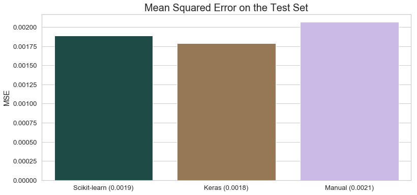

```python
# Create DataFrame of the experimental data
mse_s = metrics.mean_squared_error(y_test, y_pred_s)
mse_k = metrics.mean_squared_error(y_test, y_pred_k)
mse_m = metrics.mean_squared_error(y_test, y_pred_m)
mses = [mse_s, mse_k, mse_m]
experimental_data = {"MSE": mses,
                     "Implementation": ["{} ({:.4f})".format(n, mses[i]) for i, n in enumerate(implementation_names)]}

# Display a bar plot of the test set mean squared errors
sns.set(font_scale=1.2, style="whitegrid")
plt.figure(figsize=(13, 6))
ax = sns.barplot(x="Implementation", y="MSE", data=experimental_data, palette="cubehelix")
ax.set_title("Mean Squared Error on the Test Set", fontsize=20)
ax.set_ylabel("MSE", fontsize=15)
plt.show()
```

#### 5.1.3. Mean Absolute Error on the Test Set

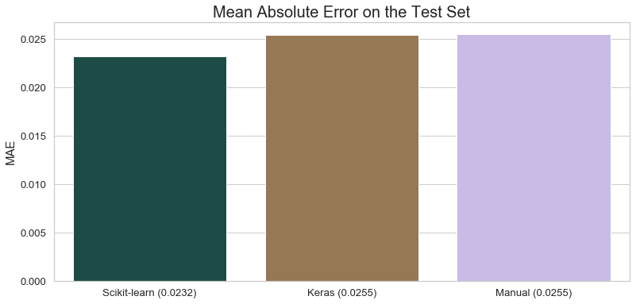

```python
# Create DataFrame of the experimental data
mae_s = metrics.mean_absolute_error(y_test, y_pred_s)
mae_k = metrics.mean_absolute_error(y_test, y_pred_k)
mae_m = metrics.mean_absolute_error(y_test, y_pred_m)
maes = [mae_s, mae_k, mae_m]
experimental_data = {"MAE": maes,
                     "Implementation": ["{} ({:.4f})".format(n, maes[i]) for i, n in enumerate(implementation_names)]}

# Display a bar plot of the test set mean absolute errors
sns.set(font_scale=1.2, style="whitegrid")
plt.figure(figsize=(13, 6))
ax = sns.barplot(x="Implementation", y="MAE", data=experimental_data, palette="cubehelix")
ax.set_title("Mean Absolute Error on the Test Set", fontsize=20)
ax.set_ylabel("MAE", fontsize=15)
plt.show()
```

#### 5.1.4. Total Training Time

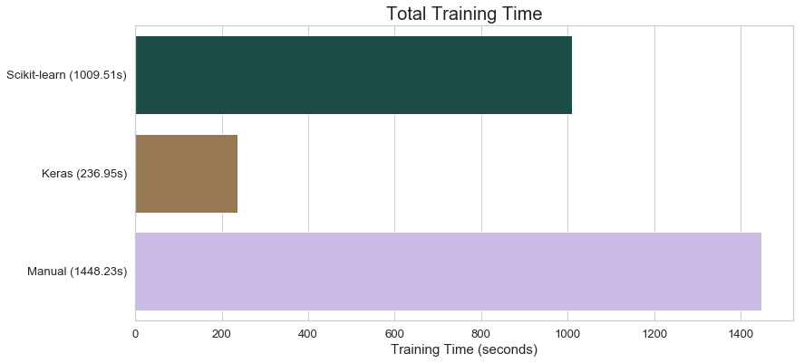

```python
# Create DataFrame of the experimental data
experimental_data = {"Training Time": training_durations,
                     "Implementation": ["{} ({:.2f}s)".format(n, training_durations[i]) for i, n in \
                                        enumerate(implementation_names)]}

# Display a bar plot of the training durations
sns.set(font_scale=1.2, style="whitegrid")
plt.figure(figsize=(13, 6))
ax = sns.barplot(x="Training Time", y="Implementation", data=experimental_data, palette="cubehelix")
ax.set_title("Total Training Time", fontsize=20)
ax.set_xlabel("Training Time (seconds)", fontsize=15)
plt.show()
```

#### 5.1.5. Property Sale Price Predictions

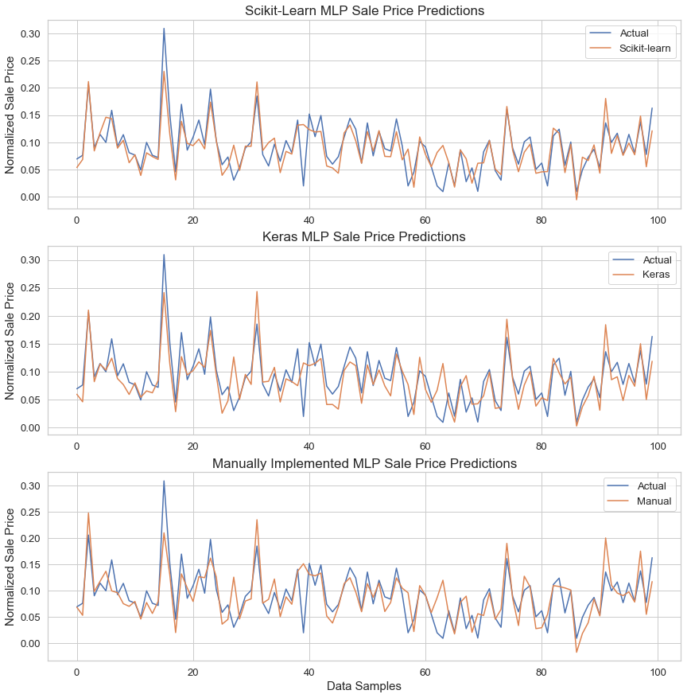

```python
# Create DataFrames of the experimental data
display_range = 100

y_test_graph = list(y_test)[200:300]
y_pred_s_graph = list(y_pred_s)[200:300]
y_pred_k_graph = list(y_pred_k)[200:300]
y_pred_m_graph = list(y_pred_m)[200:300]

experimental_data_s = {"Sale Price (Rubles)": y_test_graph + y_pred_s_graph,
                       "Data Samples": [i for i in range(display_range)] * 2,
                       "Implementation": np.ravel([[n] * display_range for n in ["Actual", "Scikit-learn"]])}
experimental_data_k = {"Sale Price (Rubles)": y_test_graph + y_pred_k_graph,
                       "Data Samples": [i for i in range(display_range)] * 2,
                       "Implementation": np.ravel([[n] * display_range for n in ["Actual", "Keras"]])}
experimental_data_m = {"Sale Price (Rubles)": y_test_graph + y_pred_m_graph,
                       "Data Samples": [i for i in range(display_range)] * 2,
                       "Implementation": np.ravel([[n] * display_range for n in ["Actual", "Manual"]])}

# Display line plots of the multilayer perceptron predictions for the test set
sns.set(font_scale=1.2, style="whitegrid")

fig, ax = plt.subplots(figsize=(12, 12))
fig.tight_layout()

plt.subplot(3, 1, 1)
plt.title("Scikit-Learn MLP Sale Price Predictions", fontsize=17)
sns.lineplot(x="Data Samples", y="Sale Price (Rubles)", hue="Implementation", data=experimental_data_s)
plt.ylabel("Normalized Sale Price", fontsize=15)

plt.subplot(3, 1, 2)
plt.title("Keras MLP Sale Price Predictions", fontsize=17)
sns.lineplot(x="Data Samples", y="Sale Price (Rubles)", hue="Implementation", data=experimental_data_k)
plt.ylabel("Normalized Sale Price", fontsize=15)

plt.subplot(3, 1, 3)
plt.title("Manually Implemented MLP Sale Price Predictions", fontsize=17)
sns.lineplot(x="Data Samples", y="Sale Price (Rubles)", hue="Implementation", data=experimental_data_m)
plt.ylabel("Normalized Sale Price", fontsize=15)
plt.xlabel("Data Samples", fontsize=15)

plt.show()
```

#### 5.2. Hyperparameter Experimentation

This subsection investigates the effects of different hyperparameters on the training and performance of the multilayer perceptron. Specifically, we investigation variations in the learning rate, variations in the mini-batch size, and variations in the number of hidden layer neurons. We compare each variation by examining the network's mean squared error on the training set over training epochs, and the network's mean absolute error on the test set.

Note that the manual implementation of the multilayer perceptron was used for all of the hyperparameter experiments.

#### 5.2.1. Variation in Learning Rate

```python
# Fix other hyperparameters for the experiment
epochs = 1000
verbose = False
batch_size = 128
hidden_layer_size = 512

# Define the learning rates to use within the experiment
learning_rates = [0.0001, 0.0005, 0.001, 0.005, 0.01]
```

```python
# Record the MSE over training epochs and the predicted sale prices for each learning rate
mse_over_epochs = []
sale_price_predictions = []

for lr in learning_rates:

    # Manually implemented Multilayer Perceptron
    y_pred_m, history_m = manual_MLP(x_train, y_train_manual, x_test, epochs, verbose, batch_size, lr, hidden_layer_size)

    mse_over_epochs += history_m
    sale_price_predictions.append(y_pred_m)
```

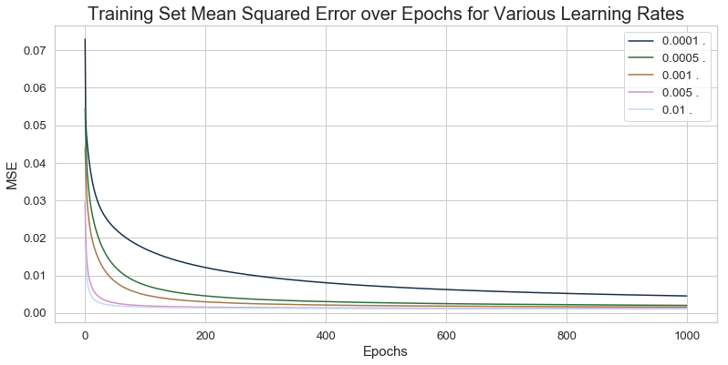

```python
# Create DataFrame of the experimental data
experimental_data = {"Epochs": [i for i in range(epochs)] * len(learning_rates),
                     "MSE": mse_over_epochs,
                     "Learning Rate": np.ravel([["{} .".format(lr)] * epochs for lr in learning_rates])}

# Display a line plot of the training set mean squared errors for various learning rate experiments
# as the number of epochs increases
sns.set(font_scale=1.2, style="whitegrid")
plt.figure(figsize=(13, 6))
ax = sns.lineplot(x="Epochs", y="MSE", hue="Learning Rate", data=experimental_data, palette="cubehelix")
ax.set_title("Training Set Mean Squared Error over Epochs for Various Learning Rates", fontsize=20)
ax.set_ylabel("MSE", fontsize=15)
ax.set_xlabel("Epochs", fontsize=15)
plt.show()
```

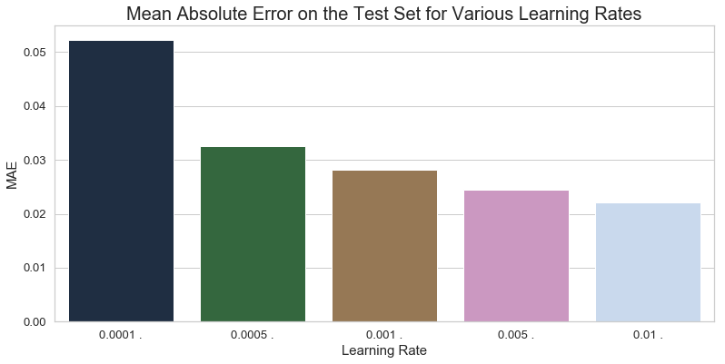

```python
# Create DataFrame of the experimental data
maes = []
for y_ps in sale_price_predictions:
    maes.append(metrics.mean_absolute_error(y_test, y_ps))
experimental_data = {"MAE": maes,
                     "Learning Rate": np.ravel([["{} .".format(lr)] for lr in learning_rates])}

# Display a bar plot of the test set mean absolute errors
sns.set(font_scale=1.2, style="whitegrid")
plt.figure(figsize=(13, 6))
ax = sns.barplot(x="Learning Rate", y="MAE", data=experimental_data, palette="cubehelix")
ax.set_title("Mean Absolute Error on the Test Set for Various Learning Rates", fontsize=20)
ax.set_ylabel("MAE", fontsize=15)
ax.set_xlabel("Learning Rate", fontsize=15)
plt.show()
```

#### 5.2.2. Variation in Mini-batch Size

```python
# Fix other hyperparameters for the experiment
epochs = 100
verbose = False
learning_rate = 0.001
hidden_layer_size = 512

# Define the mini-batch sizes to use within the experiment
batch_sizes = [1, 32, 64, 128, 256]
```

```python
# Record the MSE over training epochs and the predicted sale prices for each mini-batch size
mse_over_epochs = []
sale_price_predictions = []

for mbs in batch_sizes:

    # Manually implemented Multilayer Perceptron
    y_pred_m, history_m = manual_MLP(x_train, y_train_manual, x_test, epochs, verbose, mbs, learning_rate, hidden_layer_size)

    mse_over_epochs += history_m
    sale_price_predictions.append(y_pred_m)
```

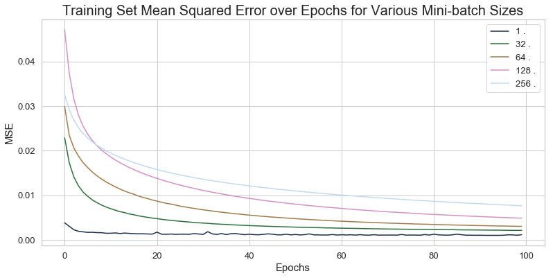

```python
# Create DataFrame of the experimental data
experimental_data = {"Epochs": [i for i in range(epochs)] * len(batch_sizes),
                     "MSE": mse_over_epochs,
                     "Mini-batch Size": np.ravel([["{} .".format(mbs)] * epochs for mbs in batch_sizes])}

# Display a line plot of the training set mean squared errors for various mini-batch size experiments
# as the number of epochs increases
sns.set(font_scale=1.2, style="whitegrid")
plt.figure(figsize=(13, 6))
ax = sns.lineplot(x="Epochs", y="MSE", hue="Mini-batch Size", data=experimental_data, palette="cubehelix")
ax.set_title("Training Set Mean Squared Error over Epochs for Various Mini-batch Sizes", fontsize=20)
ax.set_ylabel("MSE", fontsize=15)
ax.set_xlabel("Epochs", fontsize=15)
plt.show()
```

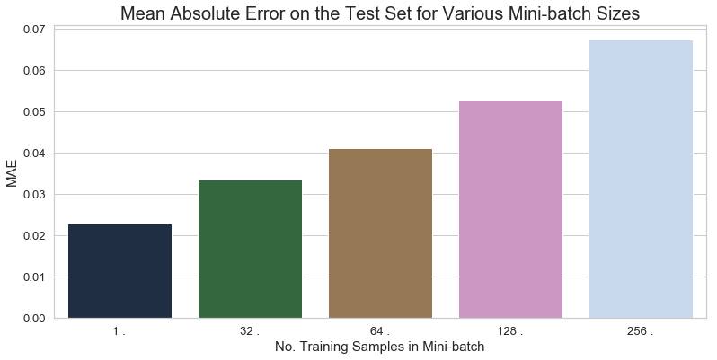

```python
# Create DataFrame of the experimental data
maes = []
for y_ps in sale_price_predictions:
    maes.append(metrics.mean_absolute_error(y_test, y_ps))
experimental_data = {"MAE": maes,
                     "No. Training Samples in Mini-batch": np.ravel([["{} .".format(mbs)] for mbs in batch_sizes])}

# Display a bar plot of the test set mean absolute errors
sns.set(font_scale=1.2, style="whitegrid")
plt.figure(figsize=(13, 6))
ax = sns.barplot(x="No. Training Samples in Mini-batch", y="MAE", data=experimental_data, palette="cubehelix")
ax.set_title("Mean Absolute Error on the Test Set for Various Mini-batch Sizes", fontsize=20)
ax.set_ylabel("MAE", fontsize=15)
ax.set_xlabel("No. Training Samples in Mini-batch", fontsize=15)
plt.show()
```

#### 5.2.3. Variation in the Number of Hidden Layer Neurons

```python
# Fix other hyperparameters for the experiment
epochs = 100
verbose = False
batch_size = 128
learning_rate = 0.001

# Define the hidden layer sizes to use within the experiment
hidden_layer_sizes = [64, 128, 256, 512, 1024]
```

```python
# Record the MSE over training epochs and the predicted sale prices for each hidden layer size
mse_over_epochs = []
sale_price_predictions = []

for hls in hidden_layer_sizes:

    # Manually implemented Multilayer Perceptron
    y_pred_m, history_m = manual_MLP(x_train, y_train_manual, x_test, epochs, verbose, batch_size, learning_rate, hls)

    mse_over_epochs += history_m
    sale_price_predictions.append(y_pred_m)
```

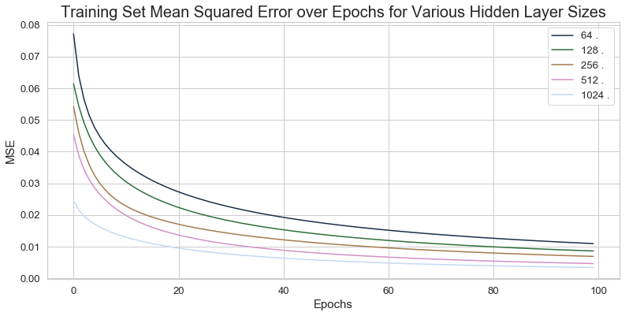

```python
# Create DataFrame of the experimental data
experimental_data = {"Epochs": [i for i in range(epochs)] * len(hidden_layer_sizes),
                     "MSE": mse_over_epochs,
                     "Hidden Layer Size": np.ravel([["{} .".format(hls)] * epochs for hls in hidden_layer_sizes])}

# Display a line plot of the training set mean squared errors for various hidden layer size experiments
# as the number of epochs increases
sns.set(font_scale=1.2, style="whitegrid")
plt.figure(figsize=(13, 6))
ax = sns.lineplot(x="Epochs", y="MSE", hue="Hidden Layer Size", data=experimental_data, palette="cubehelix")
ax.set_title("Training Set Mean Squared Error over Epochs for Various Hidden Layer Sizes", fontsize=20)
ax.set_ylabel("MSE", fontsize=15)
ax.set_xlabel("Epochs", fontsize=15)
plt.show()
```

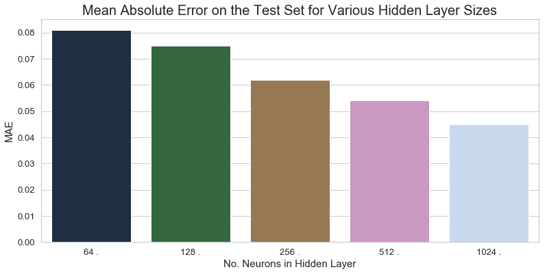

```python
# Create DataFrame of the experimental data
maes = []
for y_ps in sale_price_predictions:
    maes.append(metrics.mean_absolute_error(y_test, y_ps))
experimental_data = {"MAE": maes,
                     "No. Neurons in Hidden Layer": np.ravel([["{} .".format(hls)] for hls in hidden_layer_sizes])}

# Display a bar plot of the test set mean absolute errors
sns.set(font_scale=1.2, style="whitegrid")
plt.figure(figsize=(13, 6))
ax = sns.barplot(x="No. Neurons in Hidden Layer", y="MAE", data=experimental_data, palette="cubehelix")
ax.set_title("Mean Absolute Error on the Test Set for Various Hidden Layer Sizes", fontsize=20)
ax.set_ylabel("MAE", fontsize=15)
ax.set_xlabel("No. Neurons in Hidden Layer", fontsize=15)
plt.show()
```

#### 5.3. Predicting Russian House Prices based upon Information about the Property and the Surrounding Area

Here we explore a potential use case for the multilayer perceptron within the domain of the Russian housing market. Being able to estimate the sale price of a property would be useful in many situations. Property sellers want to know the expected sale price of their property so that they have a general idea of what they will get from selling their home. Property buyers want to know what a property is worth so that they do not overpay for a property and so that they can strategically make offers. Banks would like to know what a property is objectively worth so that they can more easily conduct bank valuations on properties, and real estate agencies would like to know the estimated property sale price for a similar reason, as they frequently conduct home appraisals and privately ordered valuations for their clients. The previous points outline that there is clearly a practical application for this technology within the domain of the Russian housing market. Consequently, we decided to implement an algorithm that predicts the sale price of properties given some information about the property and surrounding area.

In order to predict the sale price of properties given some information about the property and surrounding area, we will firstly train a multilayer perceptron to accurately learn a mathematical function that maps an input vector of property and surrounding area attributes to a single continuous valued output representing the property sale price. Then, when a user would like to find out the price of a particular property with certain characteristics, we will collect their specified property and surrounding area characteristics and add them to a feature vector that can be input into the MLP. For the attributes that were not specified by the user, we will calculate their average values from the training set and use those values for the remaining elements of the feature vector. We can then simply pass the feature vector through the MLP and report to the user the predicted property sale price based upon the property and surrounding area characteristics they specified.

Note that the manual implementation of the multilayer perceptron was used in the property price predictor algorithm.

```python
class PropertyPricePredictor:
    """ Property Sale Price Predictor for the Russian Housing Market."""

    def __init__(self, x_train, y_train):
        """ Initialises variables for the PropertyPricePredictor class.

        :param x_train: Two dimensional array containing the training set feature vectors.
        :param y_train: One dimensional array containing the training set target values.
        :var x_train_mean: One dimensional array containing the training set feature vector attribute means.
        :var mlp: A ManualMLP class object representing a multilayer perceptron.
        """

        # Calculate the mean value for each of the input vector attributes in the training set
        self.x_train_mean = np.mean(x_train, axis=0)

        # Define hyperparameters for the training the multilayer perceptron
        epochs = 1000
        verbose = False
        batch_size = 128
        learning_rate = 0.001
        hidden_layer_size = 1024

        # Create a Multilayer Perceptron (using the manual implementation)
        self.mlp = ManualMLP(shape=(x_train.shape[1], hidden_layer_size, 1))

        # Train the model on the training set
        _ = self.mlp.train(x_train, y_train, epochs=epochs, batch_size=batch_size, eta=learning_rate, verbose=verbose)

    def predict_price(self, characteristics_dict, preprocess=True):
        """ Accepts the user input property and surrounding area characteristics and returns the predicted property price.

        :param characteristics_dict: A dictionary mapping "attribute name" to "specified value" for each of the user
                                     input property and surrounding area characteristics. For example:
                                     {"floor": 1, "num_room": 3, "sub_area": "Bibirevo", "park_km": "1.5"}
        :param preprocess: A Boolean value specifying whether or not the characteristics_dict needs to be preprocessed or not.
        :return: A floating point value representing the predicted property price in Russian rubles.
        """

        # Define input feature vector
        feature_vector = self.x_train_mean.copy()

        # Preprocess the user input property and surrounding area values
        for a in characteristics_dict.keys():
            value = characteristics_dict[a]

            if preprocess:

                # Perform Data Transformation and Data Discretization
                if a in attribute_encoders.keys():
                    value = attribute_encoders[a].transform(np.array([value]))
                    value = value[0]

                # Data Standardization
                value = attribute_standardizers[a].transform(np.array([value], dtype=np.float64).reshape(1, -1))

            # Add value to the input feature vector
            feature_vector[standardized_columns.index(a)] = value

        # Predict the property sale price based upon property and neighbourhood attributes
        y_pred = self.mlp.predict(np.array([feature_vector]))

        # Reverse the normalization applied to the `price_doc` attribute since we are predicting property sale prices
        y_pred = reverse_normalize(y_pred, price_doc_min, price_doc_max)

        # Return predicted property price
        return y_pred[0]
```

```python
# Create a PropertyPricePredictor class object
predictor = PropertyPricePredictor(x_train, y_train_manual)
```

#### 5.3.1. Algorithm Use Cases

Example attribute values to use:

```
|----------------------------------------------------------------------------------------|
| Attribute    | Description                           | Value Range                     |
|----------------------------------------------------------------------------------------|
| full_sq      | total area in square meters           | [10.0, 637.0]                   |
| life_sq      | living area in square meters          | [0, 637.0]                      |
| floor        | for apartments, floor of the building | [0, 77]                         |
| max_floor    | number of floors in the building      | [0, 117]                        |
| build_year   | year built                            | [1860, 2019]                    |
| num_room     | number of living rooms                | [0, 19]                         |
| product_type | owner-occupier purchase or investment | {"OwnerOccupier", "Investment"} |
| sub_area     | name of the district                  | {"Ajeroport", ..., "Zjuzino"}   |
|----------------------------------------------------------------------------------------|
```

```python
def property_price_predictor(predictor, input_dict):

    # Predict property sale price given the provided characteristics
    predicted_price = predictor.predict_price(input_dict)

    # Display output to the user
    print("The predicted property price is {} rubles (i.e. ${} AUD)".format(int(predicted_price), int(predicted_price * 0.023)))
```

```python
# Example use case 1
property_price_predictor(predictor, {"full_sq": 100, "life_sq": 50, "floor": 1})
```

```
The predicted property price is 15910318 rubles (i.e. $365937 AUD)
```

```python
# Example use case 2
property_price_predictor(predictor, {"build_year": 2017, "num_room": 5, "product_type": "OwnerOccupier"})
```

```
The predicted property price is 9051830 rubles (i.e. $208192 AUD)
```

```python
# Example use case 3
property_price_predictor(predictor, {"build_year": 2000, "num_room": 5, "product_type": "OwnerOccupier"})
```

```
The predicted property price is 8837248 rubles (i.e. $203256 AUD)
```

```python
# Example use case 4
property_price_predictor(predictor, {"max_floor": 5, "sub_area": "Ajeroport"})
```

```
The predicted property price is 7949091 rubles (i.e. $182829 AUD)
```

#### 5.3.2. Convergence Towards Actual Sale Price

```python
# Reverse the normalization applied to the `price_doc` attribute
y_test_reverse_norm = reverse_normalize(y_test, price_doc_min, price_doc_max)
```

```python
# Select a test sample
index = 1
y_sample = y_test_reverse_norm[index]
x_sample = x_test[index]

# Collect property sale price predictions from the PropertyPricePredictor as the number of true attribute values increases
sale_price_predictions = []
for i in range(len(standardized_columns) + 1):

    # Create input dictionary
    input_dict = {}
    for j in range(i):
        input_dict[standardized_columns[j]] = x_sample[j]

    # Predict property sale price
    predicted_price = predictor.predict_price(input_dict, preprocess=False)
    sale_price_predictions.append(predicted_price)
```

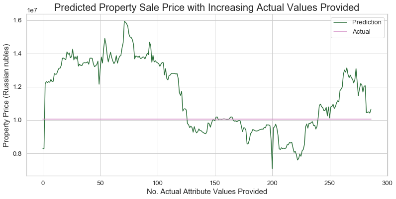

```python
# Create DataFrame of the experimental data
experimental_data = {"No. Actual Attribute Values": [i for i in range(len(standardized_columns) + 1)] * 2,
                     "Property Price": sale_price_predictions + [y_sample for i in range(len(standardized_columns) + 1)],
                     "Identifier": np.ravel([[i] * (len(standardized_columns) + 1) for i in ["Prediction", "Actual"]])}

# Display a line plot of the PropertyPricePredictor property sale price predictions as the number of actual attribute values
# provided increases
sns.set(font_scale=1.2, style="whitegrid")
plt.figure(figsize=(13, 6))
ax = sns.lineplot(x="No. Actual Attribute Values", y="Property Price", hue="Identifier", data=experimental_data,
                  palette="cubehelix")
ax.set_title("Predicted Property Sale Price with Increasing Actual Values Provided", fontsize=20)
ax.set_ylabel("Property Price (Russian rubles)", fontsize=15)
ax.set_xlabel("No. Actual Attribute Values Provided", fontsize=15)
plt.show()
```